# Group-12

# Data Cleaning

In this process we are cleaning the data by removing unnecssary columns that are not rqeuired for our analysis. WE had already checked for missing values and outliers using Microsoft Excel.

```r
# Load the dplyr package if not already loaded
# install.packages("dplyr")
library(dplyr)

# Specify columns to remove
cols_to_remove <- c("FGA", "FG%", "3PM", "3PA", "3P%", "FTM", "FTA", "FT%", "OREB", "DREB", "REB", "AST", "TOV", "STL", "BLK", "PF", "FP", "DD2", "TD3")

# Remove specified columns from nba_data
nba_data <- nba_data %>%
  select(-one_of(cols_to_remove))

# Display the remaining column names
colnames(nba_data)
```

```
##  [1] "PName" "POS"   "Team"  "Age"   "GP"    "W"     "L"     "Min"   "PTS"
## [10] "FGM"   "+/-"
```

## Exploratory Data Analysis

Using EDA we want to understand and determine the relationships between the variables present in our data set. We performed different analyisis such as bivariate, correlation and Heatmap.

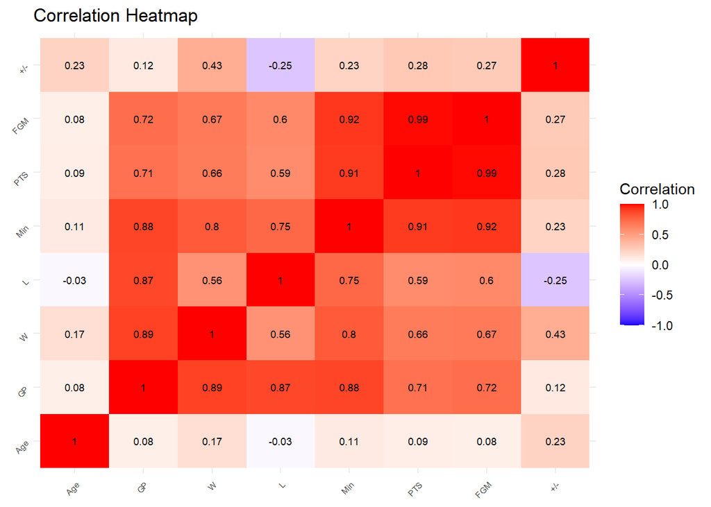

```r
library(readr)
library(dplyr)
library(ggplot2)
library(reshape2)
# Select only the numeric columns for the correlation matrix
numeric_data <- nba_data %>% select_if(is.numeric)

# Calculate the correlation matrix
correlation_matrix <- cor(numeric_data, use = "complete.obs", method = "pearson")

# Melt the correlation matrix into a long format suitable for ggplot2
melted_correlation_matrix <- melt(correlation_matrix)

# Create the heatmap
heatmap_plot <- ggplot(melted_correlation_matrix, aes(Var1, Var2, fill = value)) +
  geom_tile() +
  geom_text(aes(label = round(value, 2)), color = "black", size = 2.5) + # Adjust text size as needed
  scale_fill_gradient2(low = "blue", high = "red", mid = "white",
                       midpoint = 0, limit = c(-1, 1), space = "Lab",
                       name="Correlation") +
  theme_minimal() +
  theme(axis.text.x = element_text(angle = 45, hjust = 1, size = 6), # Adjust text angle and size as needed
        axis.text.y = element_text(angle = 45, hjust = 1, size = 6), # Adjust text angle and size as needed
        axis.title = element_blank(),
        legend.position = "right") +
  labs(title = "Correlation Heatmap")

# Print the heatmap
print(heatmap_plot)
```

# Bivariate Analysis

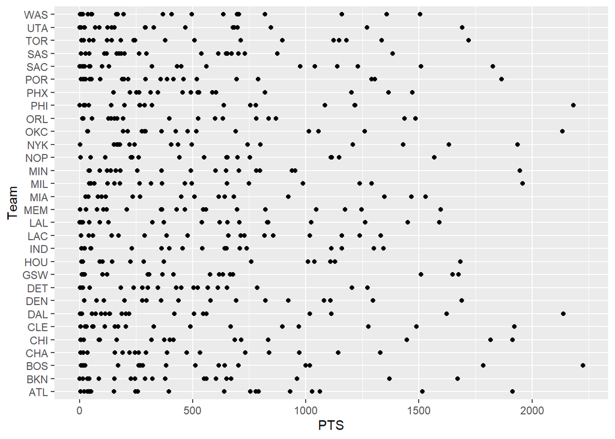

```r
# Scatter plot for two numerical variables
ggplot(nba_data, aes(x = PTS, y = Team)) + geom_point()
```

# Correlation Analysis

```r
# Correlation matrix for numerical variables
cor(nba_data %>% select(PTS, W, L))
```

```
##          PTS         W         L
## PTS 1.000000 0.6602660 0.5880090
## W   0.660266 1.0000000 0.5559321
## L   0.588009 0.5559321 1.0000000
```

# Heatmap

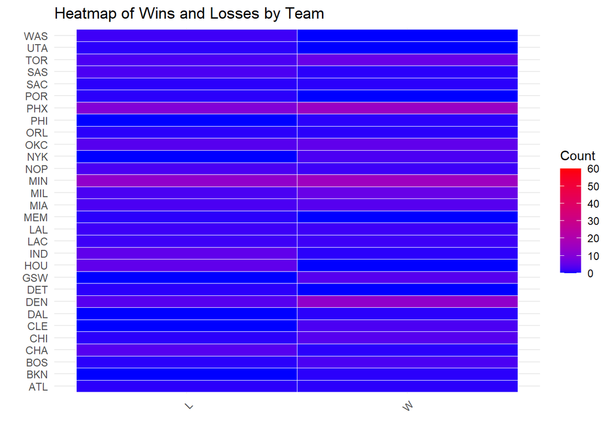

```r
# We'll first gather the wins and losses into a 'long' format
nba_long <- nba_data %>%
  select(Team, W, L) %>%
  gather(key = "Statistic", value = "Value", -Team)
# Now we can plot the heatmap
ggplot(nba_long, aes(x = Statistic, y = Team, fill = Value)) +
  geom_tile(color = "white") + # Add a white border for each tile
  scale_fill_gradient(low = "blue", high = "red") + # Gradient fill based on the Value
  theme_minimal() + # Minimal theme
  labs(x = "", y = "", title = "Heatmap of Wins and Losses by Team", fill = "Count") +
  theme(axis.text.x = element_text(angle = 45, hjust = 1)) # Rotate X labels for clarity
```

# 2.Data Preparation and parititioning using ’set.seed(5555)

```r
set.seed(5555)
nba_data$AgeCat <- cut(nba_data$Age, breaks = c(0, 25, 30, Inf), labels = c("Young", "Prime", "Veteran"))
#splitting the data into 80,20.
train_rows <- round(nrow(nba_data) * 0.8)
train_index <- sample(1:nrow(nba_data), train_rows)
train <- nba_data[train_index, ]
test <- nba_data[-train_index, ]
```

# 3.Model Construction

Data modeling is main part of this process, as we can visualize the structure of the data that we have and try to organize the data elements and how these data elements are related to each other. With this process, we can understand whether the model that we are building on a set of data can meet the requirements of the system based on the results and performance of the model. Our target variable is age category that we are creating based on the ages and our response variables are PTS, W, and L.We partitioned our data with 80 percent training data and 20 percent validation data with seed as 5555. We want to use the following three models as in our project: # Decision Tree As we want to identify the relationship between age categories and performance metrics, I feel decision tree is better as these are very complex characteristics.Even using decision tree can also handle numerical data and categorical data. Utlimately, we felt decision tree is better for our analysis. # Random Forest We are choosing Random Forest as it is beneficial for different types of datasets and mostly when the relationship between predictors and target variables is complex. As our research statement is to capture the non linear relationship between age and performance we felt random forest is best suited. And also compared to other model random forest is less sensitive to outliers if there are any. # Gradient boosting model. As we all know Gradient boosting model is very powerful technique and helps in reducing bias and weakness and makes predictions which are better than random chances we felt os using gradient boosting model. #Logistic regression model. We all know that logitic regression model is the most used for classification tasks. We want to use this model and know the probability of young and prime age categories. So we have chosen logitic regression model as our fourth model just to see how the model performs.

# 4.Model Selection/Validation

# Decision Tree

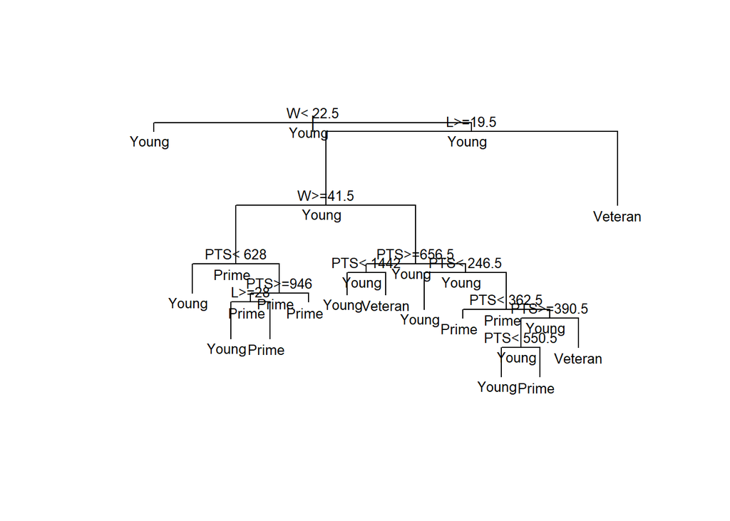

```r
library(rpart)
#training decision tree
tree_model <- rpart(AgeCat ~ PTS + W + L, data = train, method = "class")
#plotting the decision tree
plot(tree_model,margin = 0.1)
text(tree_model, cex = 0.8, all = TRUE)
```

```r
#predicting on the validation or test data
predictions <- predict(tree_model, newdata = test, type = "class")
# Evaluating the model
confumatrix <- table(predictions, test$AgeCat)
print(confumatrix)
```

```
##
## predictions Young Prime Veteran
##     Young      45    24      10
##     Prime       6     7       2
##     Veteran     5     8       1
```

```r
# Calculating accuracy, precision, recall and f1 score
accuracy <- sum(diag(confumatrix)) / sum(confumatrix)
print(paste("Accuracy:", accuracy))
```

```
## [1] "Accuracy: 0.490740740740741"
```

```r
precision <- diag(confumatrix) / rowSums(confumatrix)
recall <- diag(confumatrix) / colSums(confumatrix)
f1score <- 2 * (precision * recall) / (precision + recall)
for (i in seq_along(precision)) {
  print(paste("Class:", levels(test$AgeCat)[i]))
  print(paste("Precision:", precision[i]))
  print(paste("Recall:", recall[i]))
  print(paste("F1-Score:", f1score[i]))
}
```

```
## [1] "Class: Young"
## [1] "Precision: 0.569620253164557"
## [1] "Recall: 0.803571428571429"
## [1] "F1-Score: 0.666666666666667"
## [1] "Class: Prime"
## [1] "Precision: 0.466666666666667"
## [1] "Recall: 0.179487179487179"
## [1] "F1-Score: 0.259259259259259"
## [1] "Class: Veteran"
## [1] "Precision: 0.0714285714285714"
## [1] "Recall: 0.0769230769230769"
## [1] "F1-Score: 0.0740740740740741"
```

# Random Forest

```r
library(randomForest)
set.seed(5555)
rf_model <- randomForest(AgeCat ~ PTS + W + L, data = train, ntree = 100, importance = TRUE)
predictionsrf <- predict(rf_model, newdata = test)
# Evaluating model
confumatrix_rf <- table(predictionsrf, test$AgeCat)
print(confumatrix_rf)
```

```
##
## predictionsrf Young Prime Veteran
##       Young      43    25       8
##       Prime       9    11       4
##       Veteran     4     3       1
```

```r
accuracyrf <- sum(diag(confumatrix_rf)) / sum(confumatrix_rf)
print(paste("Accuracy:", accuracyrf))
```

```
## [1] "Accuracy: 0.509259259259259"
```

```r
precision <- diag(confumatrix_rf) / rowSums(confumatrix_rf)
recall <- diag(confumatrix_rf) / colSums(confumatrix_rf)
f1score <- 2 * (precision * recall) / (precision + recall)
for (i in seq_along(precision)) {
  print(paste("Class:", levels(test$AgeCat)[i]))
  print(paste("Precision:", precision[i]))
  print(paste("Recall:", recall[i]))
  print(paste("F1-Score:", f1score[i]))
}
```

```
## [1] "Class: Young"
## [1] "Precision: 0.565789473684211"
## [1] "Recall: 0.767857142857143"
## [1] "F1-Score: 0.651515151515152"
## [1] "Class: Prime"
## [1] "Precision: 0.458333333333333"
## [1] "Recall: 0.282051282051282"
## [1] "F1-Score: 0.349206349206349"
## [1] "Class: Veteran"
## [1] "Precision: 0.125"
## [1] "Recall: 0.0769230769230769"
## [1] "F1-Score: 0.0952380952380952"
```

```r
# Printing variable importance
print("Variable Importance:")
```

```
## [1] "Variable Importance:"
```

```r
print(round(importance(rf_model), 2))
```

```
##     Young Prime Veteran MeanDecreaseAccuracy MeanDecreaseGini
## PTS  2.34 -1.46    2.10                 2.33            90.84
## W    5.89  0.55   -0.64                 5.65            72.76
## L    9.55  2.53   -6.20                 7.37            73.74
```